# Broken Stick Model for Irregular Longitudinal Data

# Methodology

## Notation

We adopt the notation of Fitzmaurice, Laird, and Ware (2011). Let $Y_{ij}$ denote the response variable for the $i^{\rm th}$ subject on the $j^{\rm th}$ measurement occasion at time $t_{ij}$. Data are collected in a sample of $N$ persons $i=1,\dots,N$. Let repeated measurements for the $i^{\rm th}$ subject be grouped as
$$Y_i = \left( \begin{array} {l} Y_{i1} \\ Y_{i2} \\ \vdots \\ Y_{in_i} \end{array} \right), \quad i = 1, \dots, N.$$
If the measures have been observed at a common same set of occasions, then we could drop the index $i$ in $t_{ij}$ since $t_{ij} = t_j$ for all $i = 1, \dots, N$. Here we will focus on the case that $t_{ij}$ varies over $i$.

In addition, let use define the $n_i \times p$ matrices
$$X_i = \left( \begin{array} {llll}
X_{i11} & X_{i12} & \cdots & X_{i1p} \\
X_{i21} & X_{i22} & \cdots & X_{i2p} \\
\vdots & \vdots & \ddots & \vdots \\
X_{in_i1} & X_{in_i2} & \cdots & X_{in_ip}
\end{array} \right), \quad i = 1, \dots, N,$$
so that the rows of $X_i$ contain $p$ covariates associated with the responses at $n_i$ measurement occasions. The columns may be time-varying covariates. If a certain covariate is fixed in time (e.g. sex, treatment, education), then all values within the corresponding column in $X_i$ are identical.

## Broken stick model

The broken stick model avoids modeling observation times $t_{ij}$ directly by representing each $t_{ij}$ as its relative position within a time interval. For example, suppose $t_{ij} = 0.6$ years and that the time interval is given by 0.5-1.0 years. The position relative to the left break age is $x_{\rm left} = (1.0-0.6)/(1.0-0.5) = 0.8$, whereas relative to the right break age is $x_{\rm right} = (0.6-0.5)/(1.0-0.5) = 0.2$. In order to fit the broken stick model, we need to replace time point $t_{ij} = 0.6$ by two values: 0.8 (for break age 0.5), and 0.2 (for break age 1.0). Note that both values add up to 1. Coding time in this way simplifies modeling continuous time by a set of discrete break ages.

More specifically, let $t_{ij}$ be coded by a second-order (linear) B-spline using $k$ internal knots $\kappa$ placed at $k+1$ ordered ages
$$\kappa_0 = \kappa_1 < \dots < \kappa_k < \kappa_{k+1}$$
The internal knots $\kappa_1, \dots, \kappa_k$ correspond to the set of ages for which we obtain broken stick estimates, and it could be specified by the user. The left boundary knot $\kappa_0 = \kappa_1$ is left-anchored to the minimum time $\min(t_{ij})$ in the data. This point defines the starting event of the participant, such as birth or study enrolment. The right hand boundary knot is $\kappa_{k+1} \geq \max(t_{ij})$.

The second-order B-spline (de Boor 1978, 32),
$$H_s(t) = \left\{ \begin{array} {l@{\quad,\quad}l}
(t-\kappa_{s-1})/(\kappa_s - \kappa_{s-1}) & \kappa_{s-1} < t \leq \kappa_s,\\
(\kappa_{s+1}-t)/(\kappa_{s+1} - \kappa_s) & \kappa_s \leq t < \kappa_{s+1},\\
0 & {\rm otherwise.}
\end{array} \right.$$
is applied to $t_{ij}$ to obtain $(k+1)$ transformed variables $x_{is} = t_{ij}$ with $s = 1,\dots,k+1$. These variables can conveniently be grouped into the $n_i \times (k+1)$ matrix of covariates $X_i = (x_{i1}, \dots, x_{ik}, x_{i(k+1)})$. Each row in $X_i$ has only one or two non-zero elements, which sum to 1.

Using this $X_i$, the broken stick model is a special case (with $Z_i = X_i$) of the two-stage random-effects model (Laird and Ware 1982)

$$Y_i = X_i\beta + X_ib_i + \epsilon_i$$

where the $k+1$ column vector $\beta$ contains $k+1$ fixed effect coefficients common to all persons, where the $k+1$ column vector $b_i$ accommodates for $k+1$ subject-specific random parameters, and where the $n_i$ column vector $\epsilon_i$ holds subject-specific residuals.

In order to complete the model specification, we assume that the residuals are identically and independently distributed as $\epsilon_i \sim N(0,\sigma^2 I(n_i))$, where $\sigma^2$ is a common variance parameter, and where $I(n_i)$ is the identity matrix of order $n_i$. Thus, the equation represents population parameters (fixed effects), individual effects (random effects), and an amount of within-person dispersion that is the same for all persons. The section on estimation also considers a heterogeneous model that allows $\sigma_i^2$ to vary over subjects.

In summary, given the knot specification and the choice of the response scale, the parameters of the broken stick model are:

- $\beta$, a vector of $k + 1$ fixed parameters;
- $\Omega$, a $(k+1) \times (k+1)$ covariance matrix of the random effects;
- $\sigma^2$, the within-person error variance.

## Model assumptions

At the person level, we assume $b_i \sim N(0, \Omega)$, i.e., the random coefficients of the subjects have a multivariate normal distribution with zero mean and a $(k+1) \times (k+1)$ covariance matrix $\Omega$. The base model allows the elements of $\Omega$ to vary freely. For time-dependent data, constrained versions for $\Omega$ are also of interest.(Fitzmaurice, Laird, and Ware 2011, ch. 7). The estimation section highlights two such extensions. We also assume that the covariance between $b_i$ and $\epsilon_i$ is zero. For simplicity, this paper is restricted to the case where $X_i$ includes only time, and no other covariates. Also, we assume that $X_i$ has no missing data.

The broken stick model builds upon three main modeling assumptions:

- The trajectory between break ages follows a straight line. This assumption may fail for processes that are convex or concave in time. For example, human height growth in centimeters growth is concave, so setting breakpoints far apart results introduces systematic model bias. Modeling height SDS instead of raw height will prevent this bias.
- The broken stick estimates follow a joint multivariate normal distribution. As this assumption may fail for skewed measurements, it could be beneficial to transform the outcomes so that their distribution will be closer to normal.
- The data are *Missing at Random* (MAR) given the outcomes from all subjects at all observation times. This assumption is restrictive in the sense that missingness may only depend on the observed outcomes, and not on covariates other than time. At the same time, the assumption is liberal in the sense that the missingness may depend on future outcomes. While this MAR-future assumption is unusual in the literature on drop-out and observation time models, it is a sensible strategy for creating imputations that preserve relations over time, especially for intermittent missing data. Of course, the subsequent substantive analysis on the imputed data needs to be aware of the causal direction of time.

## Interpretation

Given the model estimates and the person data, we can calculate the random effect $b_i$. The *broken stick parameter* $\gamma_{is} = \beta_s + b_{is}$ is the subject-specific mean of $Y_i$ at time $\kappa_s$, $s = 1,\dots, k + 1$. The set of $\gamma_{is}$ parameters describes the mean response profile for subject $i$ by $k$ lines that connect at the $k + 1$ coordinates $(\kappa_s, \gamma_{is})$.

The broken stick parameter is the most likely value of outcome $Y_i$ for subject $i$ at time $\kappa_s$. The parameter is the centre of the posterior predictive distribution for normal $Y_i$. The two-sided $100(1-\alpha)\%$ prediction interval for the true, though often unobserved, value $Y_{i,\kappa_s}$ is equal to

$$[Y_{i,\kappa_s}^{\rm lo}, Y_{i,\kappa_s}^{\rm hi}] = \gamma_{is} \pm t_{(1-\alpha/2;N-1)}\sigma,$$
where $t_{(1-\alpha/2;N-1)}$ is the $100(1-\alpha/2)$ percentile of Student’s $t$-distribution with $N - 1$ degrees of freedom. For example, the 50% prediction interval $\gamma_{is} \pm 0.68\sigma$ will contain 50% of true values. For normal $Y_i$, the length of the 50% prediction interval is equivalent to the interquartile range (IQR). If the residual variation $\sigma^2$ is small (say $\sigma^2 < 0.1$), the IOR is about 0.22, so half of the true values will be within 0.22 SD of $\gamma_{is}$, a small difference. For large $\sigma^2$ (e.g. $\sigma^2 > 0.2$), the $\gamma_{i}$ vector is a smoothed representation of $Y_{i}$. While smoothness amplifies low-frequency features of the trajectories, it could also introduce biases in the subsequent analysis by suppressing high-frequency variation. In that case, the analyst needs to check whether this reduction in variation does not affect the parameters of substantive interest. We may restore high-frequency variation by adding random draws from the residual distribution $N(0, \sigma^2)$. From there, it is a small step to multiple imputation, a well-developed methodology for drawing valid inferences from incomplete data.(Rubin 1987; van Buuren 2018b)

If $n_i >> k$ then the broken stick model provides a parsimonious representation of the measurements. Reversely, if $n_i << k$ then the model infers plausible values for subject $i$ by building strength across persons. The broken stick model converts $n_i$ irregularly observed measurements into a new set of $k$ values $\gamma_{is}$ at common ages $\kappa_1, ..., \kappa_k$, $s = 1,\dots, k$.

Since each row in $X_i$ sums to unity, the broken stick model does not have a global intercept. The linear B-spline coding effectively replaces the global random intercept term by $k + 1$ *local intercepts*, one at each break age. The local intercept summarizes the information available in the adjacent left and right age intervals and ignores any information beyond the two adjacent knots. The broken stick estimates are thus primarily local. Outcome data observed outside the two adjacent age intervals influence the broken stick estimates only through the subject-level part of the model, in particular through $\Omega$.

# Estimation

## Main function

The `brokenstick()` function estimates the parameters of the broken stick model. The user needs to specify the outcome, the predictor and the grouping variable, as well as the location of the knots on the predictor variable. A call produces an object of class `brokenstick`:

```r
fit <- brokenstick(hgt_z ~ age | id, data = smocc_200,
                   knots = c(0, 0.5, 1, 2), boundary = c(0, 3),
                   seed = 12321)
fit
```

```
## Class        brokenstick (kr)
## Variables    hgt_z (outcome), age (predictor), id (group)
## Data         1942 (n), 36 (nmis), 200 (groups)
## Parameters   22 (total), 5 (fixed), 5 (variance), 10 (covariance), 2 (error)
## Knots        0 0.5 1 2 3
## Means        -0.1 0.087 -0.029 0.072 0.36
## Residuals    0.1 0.13 0.15 0.17 0.39 (min, P25, P50, P75, max)
## Mean resid   0.16
## R-squared    0.89
##
## Variance-covariance matrix
##         age_0 age_0.5  age_1  age_2 age_3
## age_0   1.406
## age_0.5 0.712   0.883
## age_1   0.522   0.744  0.782
## age_2   0.408   0.697  0.787  0.904
## age_3   0.505  -0.218 -0.072 -0.253 7.687
```

The object contains the model setting, the data and the results. Here we find estimates of the fixed effects $\beta$ under `means`, the residual variance $\sigma^2$ under `mean resid` and the variance-covariance matrix of the random effects $\Omega$ as `get_omega(fit)`. We calculate the broken stick estimates at the knot location as a wide matrix through the `predict()` function as follows:

```r
bse <- predict(fit, x = "knots", shape = "wide")
dim(bse)
```

```
## [1] 200   6
```

```r
head(bse, 3)
```

```
## # A tibble: 3 × 6
##      id    `0`  `0.5`     `1`     `2`    `3`
##   <dbl>  <dbl>  <dbl>   <dbl>   <dbl>  <dbl>
## 1 10001  0.786  0.252  0.0180  0.0414  0.972
## 2 10002 -0.271 -0.219 -0.438  -0.497   0.572
## 3 10003  1.67   2.00   1.27    1.10   -0.105
```

## Estimation steps explained

We may break up the estimation process into two main steps. The first step calculates the matrix of $B$-splines for the time variable `age` by the core `splines::bs()` (R Core Team 2020) function:

```r
library(splines)
data <- brokenstick::smocc_200
internal <- c(0, 0.5, 1, 2)
boundary <- c(0, 3)
X <- bs(data$age, knots = internal, Boundary.knots = boundary, degree = 1)
colnames(X) <- paste("age", c(internal, 3), sep = "_")
data <- cbind(data[, c("id", "age", "hgt_z")], X)
head(data)
```

```
##      id   age hgt_z age_0 age_0.5  age_1 age_2 age_3
## 1 10001 0.000  0.57  1.00    0.00 0.0000     0     0
## 2 10001 0.082  0.89  0.84    0.16 0.0000     0     0
## 3 10001 0.159  0.80  0.68    0.32 0.0000     0     0
## 4 10001 0.255  0.66  0.49    0.51 0.0000     0     0
## 5 10001 0.504  0.29  0.00    0.99 0.0076     0     0
## 6 10001 0.753 -0.40  0.00    0.49 0.5058     0     0
```

The numerical example shows that the `bs()` function transforms the `age` variable into five columns, the $B$-spline basis, with names like `age_0` and `age_0.5`. If `age` coincides with one of these (e.g., as in the top row), then the corresponding column receives a `1`. In all other cases, age distributes over two adjacent columns. To make things fit, we need an additional column (here `age_3`) at the last position, the right boundary knot. There is also a left boundary knot, and I have conveniently set that equal to the first breakpoint, marking the start of time. Setting `degree = 1` specifies a $B$-spline gives the broken stick model its name and its characteristic shape.

The second step is to specify the model and estimate its parameters. We have two methods for this: `"kr"` and `"lmer"`. Method `"lmer"` relies on the popular function `lme4::lmer()` (Bates et al. 2015) to fit a linear mixed normal model.

```r
library(lme4)
ctl_lmer <- lmerControl(check.conv.grad = .makeCC("warning", tol = 0.04))
f <- hgt_z ~ 0 + age_0 + age_0.5 + age_1 + age_2 + age_3 +
  (0 + age_0 + age_0.5 + age_1 + age_2 + age_3 | id)
mod_lmer <- lme4::lmer(f, data, control = ctl_lmer)
class(mod_lmer)
```

```
## [1] "lmerMod"
## attr(,"package")
## [1] "lme4"
```

The formula removes the intercept and specifies each knot as a random effect with child `id` as grouping factor. The `control` argument suppresses the warning `Model failed to converge with max|grad| = 0.0360913`. Such warnings occur often if the model has many random effects. These warnings may also be thrown if some of the child data are outliers (for example pre-terms). I found that the broken estimates generally look sound and reasonable despite the warnings. Note however that my experience derives primarily from child growth data, so there is no guarantee that this apparent robustness will hold for other types of data. Warnings from `lmer()` become less frequent for a lower number of knots, for larger samples sizes and for better behaved data.

Object `mod_lmer` has class `lmerMod` so we may use standard `plot()`, `predict()` and `summary` methods offered by the **lme4} package. Converting the result into broken stick estimates requires summing the fixed and random effects.

```r
bse_lmer <- t(t(ranef(mod_lmer)$id) + fixef(mod_lmer))
head(round(bse_lmer, 3), 3)
```

```
##       age_0 age_0.5 age_1  age_2  age_3
## 10001  0.78    0.27 -0.01  0.076  0.125
## 10002 -0.28   -0.21 -0.46 -0.478 -0.083
## 10003  1.68    1.97  1.28  1.114 -0.865
```

The calculation time of `lme4::lmer()` rapidly increases with the number of random effects. More than ten random effects (knots) takes significant time, and beyond 15 knots is generally impossible to fit. The **brokenstick** package provides another alternative, the *Kasim-Raudenbush (KR) sampler* (Kasim and Raudenbush 1998). The method simulates draws from the posterior distributions of parameters from a two-level normal model with heterogeneous within-subject variances. The speed of the Kasim-Raudenbush sampler is almost insensitive to the number of random effects and depends primarily on the total number of iterations and somewhat on sample size. This method is available as the function `kr()` in the **brokenstick** package.

```r
ctl_kr <- control_kr()
mod_kr <- kr(y = data$hgt_z, x = X, g = data$id, control = ctl_kr)
```

The call to `control_kr()` produces a list with settings for the sampler according to the conventions of the **coda** package (Plummer et al. 2006). The defaults in `control_kr()` should be reasonable across a wide range of cases. The list component `mod_kr$mod` contains various objects of class `mcmc` with the sampling history and detailed results. For example, inspect the fixed effect estimates as

```r
library(coda)
summary(mod_kr$mod$beta)
```

```
##
## Iterations = 101:300
## Thinning interval = 1
## Number of chains = 1
## Sample size per chain = 200
##
## 1. Empirical mean and standard deviation for each variable,
##    plus standard error of the mean:
##
##            Mean     SD Naive SE Time-series SE
## age_0   -0.0925 0.0805  0.00569        0.00569
## age_0.5  0.0989 0.0712  0.00503        0.00503
## age_1   -0.0163 0.0724  0.00512        0.00656
## age_2    0.1007 0.0785  0.00555        0.00641
## age_3    0.0532 0.3895  0.02754        0.10919
##
## 2. Quantiles for each variable:
##
##            2.5%     25%     50%     75%  97.5%
## age_0   -0.2346 -0.1487 -0.1011 -0.0392 0.0671
## age_0.5 -0.0484  0.0560  0.1021  0.1446 0.2344
## age_1   -0.1555 -0.0591 -0.0162  0.0310 0.1256
## age_2   -0.0447  0.0483  0.0988  0.1494 0.2554
## age_3   -0.7295 -0.2035  0.1099  0.3205 0.6948
```

Also, we may obtain trace plots and densities. For example try `plot(mod_kr$mod$beta)`.

The `"kr"` method is the default since version 2.0.0. We obtain results for method `"lmer"` as

```r
fit_lmer <- brokenstick(hgt_z ~ age | id, data = smocc_200,
                        knots = c(0, 0.5, 1, 2), boundary = c(0, 3),
                        method = "lmer", control = ctl_lmer)
head(predict(fit_lmer, x = "knots", shape = "wide"), 3)
```

```
## # A tibble: 3 × 6
##      id    `0`  `0.5`      `1`     `2`     `3`
##   <dbl>  <dbl>  <dbl>    <dbl>   <dbl>   <dbl>
## 1 10001  0.778  0.272 -0.00986  0.0757  0.125
## 2 10002 -0.278 -0.206 -0.459   -0.478  -0.0827
## 3 10003  1.68   1.97   1.28     1.11   -0.865
```

The broken stick estimates from the `kr` and `lmer` methods are similar, but not identical. In fact, substantial discrepancies may occur in areas where data are sparse, for example, at the right boundary knot. Apart from being faster for more complex models, the KR-sampler opens up interesting analytic options:

1. It is relatively easy to constrain the fitted covariance of random effects, $\Omega$, to a matrix of simple structure. Informing the sampler of the time-dependent structure of the random effect leads to stabler estimates of $\Omega$. The package currently implements two *correlations models*. These models express the correlation $\rho(t_1, t_2)$ between two Z -scores $Z_1$ and $Z_2$ at successive ages $t_1$ and $t_2$ as a function of those ages. The *Argyle model* (Argyle, Seheult, and Wooff 2008) is $\rho(t_1, t_2) = \exp(-\lambda|T_1-T_2|)$, where $T_i = \log(\tau+t_i)$ is a logarithmic rescaling of the time axis and $\rho=exp(-\lambda)$. The Cole correlation model (T. J. Cole 1995) describes the Fisher-transformed correlation as a function of the average $(t_1+t_2)/2$ and the difference $(t_2-t_1)$, including two multiplicative terms. Note that both models were proposed in the context of child growth, so may fit less well for other types of time-dependent data.
2. The Kasim-Raudenbush sampler fits the slightly more general linear-mixed model with heterogeneous within-subject variances, i.e. with a residual variance $\sigma_i^2$ per subject $i$ instead of the global residual $\sigma^2$. This makes it easier to identify, study and weight subjects based on how well they fit the model.
3. A third option is to simulate imputations as an extra step to the sampler. For subject with large $\sigma_i^2$, the random effect estimates are a too smooth representation of the data, leading to inappropriate variance estimates when those estimates are analysed as “just data.” Section 11.3 of van Buuren (2018b) pioneered a solution that constructs multiple trajectories by adding a proper amount of residual noise to random effect estimates. The variance estimation then proceeds according to the principles of multiple imputation.(Rubin 1987)

# Functionality

## Overview of brokenstick package

The **brokenstick** package contains functions to fit, predict and plot data. The main functions in the `brokenstick` package are:

| Function name | Description |
| --- | --- |
| `brokenstick()` | Fit a broken stick model to irregular data |
| `predict()` | Predict broken stick estimates |
| `plot()` | Plot individual trajectories |

The following functions are user-oriented helpers:

| Function name | Description |
| --- | --- |
| `coef()` | Extract coefficients |
| `fitted()` | Calculate fitted values |
| `get_knots()` | Obtain the knots used by model |
| `get_omega()` | Extract the variance-covariance matrix |
| `get_r2()` | Obtain proportion of explained variance |
| `model.frame()` | Extract training data |
| `model.matrix()` | Extract design matrix |
| `print()` | Print object |
| `residuals()` | Extract residuals from model |
| `summary()` | Summarise object |

The following functions implements the calculations:

| Function name | Description |
| --- | --- |
| `set_control()` | Generic control function |
| `control_kr()` | Set controls for Kasim-Raudenbush sampler |
| `kr()` | Kasim-Raudenbush sampler for two-level model |
| `EB()` | Empirical Bayes predictor for random effects (internal) |
| `make_basis()` | Create linear splines basis (internal) |

The package follows the standard R conventions for modelling objects. In some cases, the modeller does not wish to store the training data. Specify `brokenstick(..., light = TRUE)` to create a small object with just the parameter estimates. Of course, we cannot extract the original data from a light object. However, we can still use it to calculate brokenstick estimates for new cases by `predict(object, newdata = ...)`.

## Data preparation

Before we can fit the model, the data need to be in shape. The `brokenstick()` function takes tidy data in the long-form, with every observed subject-time combination in a row. This section uses the built-in `smocc_200` data, containing the heights of 200 children measured at ten visits up to two years.(Herngreen et al. 1994)

```r
library(brokenstick)
head(smocc_200, 3)
```

```
## # A tibble: 3 × 7
##      id    age sex       ga    bw   hgt hgt_z
##   <dbl>  <dbl> <chr>  <dbl> <dbl> <dbl> <dbl>
## 1 10001 0      female    40  3960  52   0.575
## 2 10001 0.0821 female    40  3960  55.6 0.888
## 3 10001 0.159  female    40  3960  58.2 0.797
```

## Calculate Z-scores

The broken stick model can fit observations in either the raw scale (cm, kg, and so on) or as a standard deviation score (SDS), or $Z$-score. The results from the analysis of the $Z$-score is preferable for several reasons:

1. For growth curves, a straight line assumption is more plausible in the $Z$-score scale;
2. Observations in the $Z$-score scale are closer to multivariate normality;
3. Analysis of $Z$-scores highlights the interesting variation within and between children;
4. Fitting $Z$-score data leads to fewer convergence issues.

It is easy to convert the measurements into the $Z$-score scale, fit the model, and convert back to the raw scale afterwards, if desired. There are several **R** packages that assist in the calculations: **AGD** (van Buuren 2018a), **anthro** (Schumacher, Borghi, and Polonsky 2020), **childsds** (Vogel 2020), **growthstandards** (Hafen 2021), **nlreferences** (van Buuren 2021) and **zscorer** (Myatt and Guevarra 2019).

The `smocc_200` data contains the height measurement both in the original scale in cm (`hgt`) and the $Z$-score scale (`hgt_z`) relative to the height references from the Fourth Dutch Growth study (Fredriks et al. 2000). For illustration, let us calculate and check height SDS using the **AGD** package.

```r
library(AGD)
z <- with(smocc_200, y2z(y = hgt,
                         x = age,
                         sex = ifelse(sex == "male", "M", "F"),
                         ref = nl4.hgt))
identical(z, smocc_200$hgt_z)
```

```
## [1] TRUE
```

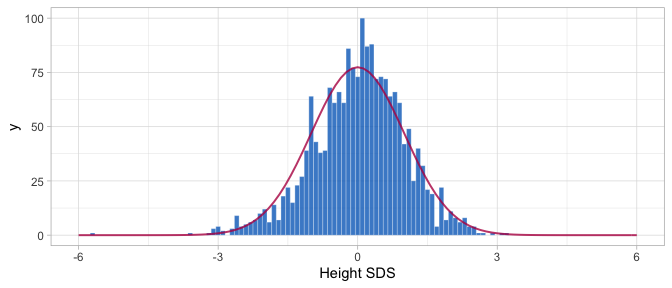

Distribution of height SDS for 200 Dutch children.

Figure 3 shows that, as expected, the empirical Z-score distribution is close to the standard normal. The few very extremely low heights correspond to pre-term born infants. The next section concentrate on modelling `hgt_z`. Function `z2y()` applies the inverse transformation of $Z$-scores to the original scale. The following snippet converts `hgt_z` into the cm scale.

```r
y <- with(smocc_200, AGD::z2y(z = hgt_z,
                              x = age,
                              sex = ifelse(sex == "male", "M", "F"),
                              ref = nl4.hgt))
all.equal(y, smocc_200$hgt, tol = 0.0001)
```

```
## [1] TRUE
```

We have used the Dutch 1997 height references here, but similar transforms could be made using other references. In practice we found that the model fit is often better when applied to $Z$-scores. Age-conditional references are common in child growth exists, but could be rare in other fields. An alternative is to apply the broken stick model to the standardized residuals of a preliminary non-linear regression of the outcome on time.

## Model fitting

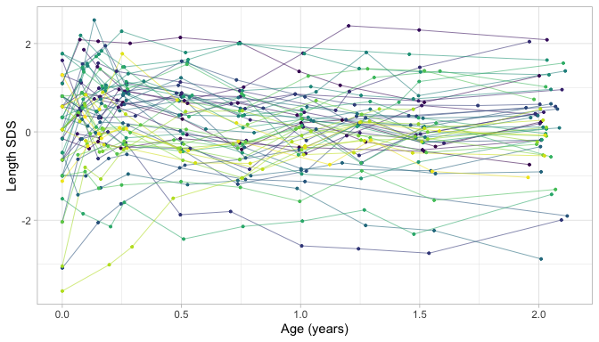

Length growth of 52 infants expressed in the Z-score scale.

Figure 4 displays the growth curves of a subset of 52 children. The $Z$-score transformation takes away the major time trend, so all trajectories are more or less flat. This display allows us to see an extremely detailed assessment of individual growth. Note how the measurements cluster around ten ages: birth, 1, 2, 3, 6, 9, 12, 15, 18 and 24 months. While the data collectors rigorously followed the study design, variation in timing is inevitable because of weekends, holidays, sickness, and other events.

### Fit one line

As a start, let us fit a simple model with just one line anchored at the minimum and maximum age.

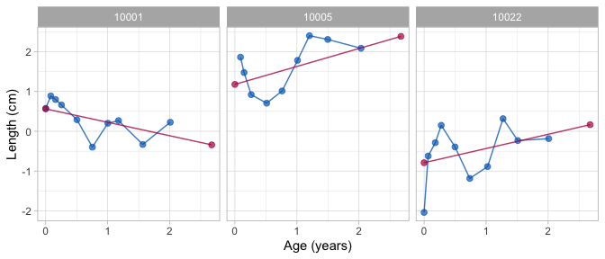

Simple linear model with one line anchored at the extremes.

```r
fit <- brokenstick(hgt_z ~ age | id, smocc_200)
ids <- c(10001, 10005, 10022)
plot(fit, group = ids, what = "all",
     xlab = "Age (years)", ylab = "Length (cm)")
```

The `what = "all"` ensures that the right boundary is part of the plot. Figure 5 shows the observed (blue) and fitted (red) trajectories of three selected children. Note that this model can only capture the overall age trend. As a result, the approximation to the data is quite bad.

### Fit two lines

We now extend to two connected lines. The first line should start at birth and end at the age of one year. The second line spans the period between one to two years. The lines must connect at the age of one year. We estimate and plot the model as follows:

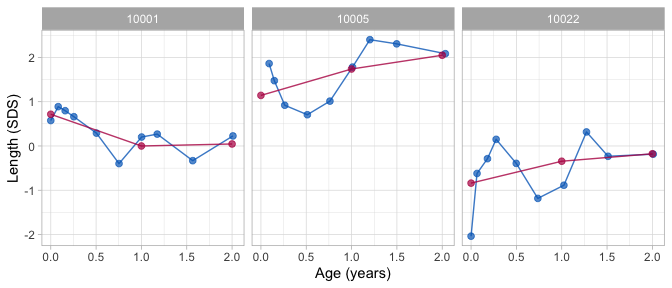

Broken stick model with two lines.

```r
fit2 <- brokenstick(hgt_z ~ age | id, smocc_200, knots = 0:2)
plot(fit2, group = ids,
     xlab = "Age (years)", ylab = "Length (SDS)")
```

The `fit2` object holds the parameter estimates of the model:

```r
fit2
```

```
## Class        brokenstick (kr)
## Variables    hgt_z (outcome), age (predictor), id (group)
## Data         1942 (n), 36 (nmis), 200 (groups)
## Parameters   16 (total), 4 (fixed), 4 (variance), 6 (covariance), 2 (error)
## Knots        0 1 2 2.7
## Means        -0.037 0.034 0.054 0.013
## Residuals    0.12 0.15 0.17 0.2 0.39 (min, P25, P50, P75, max)
## Mean resid   0.18
## R-squared    0.87
##
## Variance-covariance matrix
##             age_0 age_1  age_2 age_2.6776
## age_0         1.2
## age_1       0.493 0.843
## age_2       0.475 0.797  0.905
## age_2.6776 -0.027 0.203 -0.083       1.45
```

The printed output lists the knots of the model at 0, 1, 2 and 2.6776 years. The left and right boundaries are located at 0 and 2.6776, respectively. The `means` entry lists the fixed effect estimates, which we interpret as the average SDS per time point. The time-to-time variance-covariance matrix cover four random effects (3 visits + 1 end knot). The residual variance measures the variability of the discrepancies between the model and the observed data. These three parameters (fixed, random, residual variance) are well interpretable and fully record the fitted broken stick model.

### Fit nine lines

The two-line model does not fit well. We substantially refine the model by adding a knot for each scheduled visit. To make model specification independent of the data, we specify the right boundary as a constant of three years. We code and run the model as

```r
knots <- round(c(0, 1, 2, 3, 6, 9, 12, 15, 18, 24)/12, 4)
fit9 <- brokenstick(hgt_z ~ age | id, data = smocc_200,
                    knots = knots, boundary = c(0, 3), seed = 1)
```

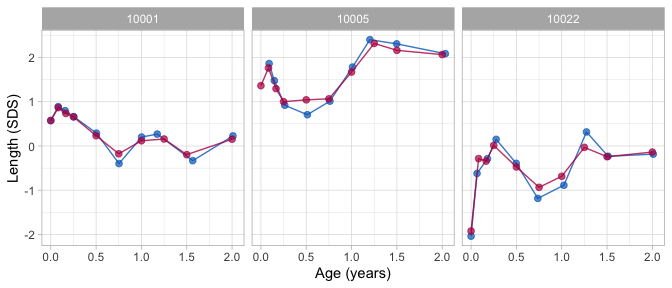

Broken stick model with nine lines.

The training set includes all subjects. Depending on the study goals, we may wish to further improve the model fit by removing children from the data. For example, there might be children for which few observations are available, children with diseases, or children with trajectories that are very unusual or faulty. Use `hist(fit9$sigma2j)` to spot the outlier. Of course, such removals may affect external generalisability.

## Prediction

Once we have a fitted model, we may obtain predictions. The subject(s) could be part of the training sample, but could also consist of new children.

### All subjects

The `predict()` function obtains predictions from the broken stick model. The function is flexible, and allows for prediction of new subjects at arbitrary ages in a variety of output formats. The simplest call

```r
p1 <- predict(fit9)
head(p1, 3)
```

```
##   .pred
## 1  0.57
## 2  0.86
## 3  0.75
```

produces the predicted value (in `.pred`) for each row in `data`.

The predicted values represent a compromise between the person’s data values and the global mean. In general, the fewer and less extreme data points of a person are, the closer the compromise will be toward the global mean. The compromise is called the *conditional mean* of the posterior distribution, the sum of the fixed and random effects.

We can obtain the locations at which the lines connect by specifying the `x = "knots"` argument, e.g.

```r
p2 <- predict(fit9, x = "knots")
head(p2, 3)
```

```
##   .source    id   age  sex ga bw hgt hgt_z .pred
## 1   added 10001 0.000 <NA> NA NA  NA    NA  0.57
## 2   added 10001 0.083 <NA> NA NA  NA    NA  0.87
## 3   added 10001 0.167 <NA> NA NA  NA    NA  0.73
```

This is case 1 in the help of `predict.brokenstick()`. The result `p2` is a table with 2200 rows (= 11 knots $\times$ 200 subjects). The rows include additional identifying information. Adding the `shape = "wide"` argument transforms the information into *repeated measures*, with 200 rows and 12 = 1 + 11 columns, that form supplemental variables for further analyses at the subject level.

We may also obtain both the conditional means as well as predictions at the observation ages for all children by

```r
p3 <- predict(fit9, x = "knots", strip_data = FALSE)
head(p3, 3)
```

```
##   .source    id   age    sex ga   bw hgt hgt_z .pred
## 1    data 10001 0.000 female 40 3960  52  0.57  0.57
## 2    data 10001 0.082 female 40 3960  56  0.89  0.86
## 3    data 10001 0.159 female 40 3960  58  0.80  0.75
```

Now suppose that we desire to predict height SDS at other ages, e.g. at 0.42, 1.33 and 4 years. We can do so by (case 4, all groups)

```r
head(predict(fit9, x = c(0.42, 1.33, 4), shape = "wide"), 3)
```

```
## # A tibble: 3 × 4
##      id `0.42`  `1.33`   `4`
##   <dbl>  <dbl>   <dbl> <dbl>
## 1 10001  0.368  0.0443    NA
## 2 10002 -0.259 -0.498     NA
## 3 10003  2.04   1.02      NA
```

Thus, we have some flexibility to work with times that are not breakpoints. Remember though that the underlying model did not change. For example, we cannot magically predict outside the model at age 4.

### Single subject

Obtaining predicted values per subject requires the `group` argument (case 3). For example

```r
predict(fit9, group = 10001, shape = "vector")
```

```
##  [1]  0.57  0.86  0.75  0.65  0.23 -0.17  0.12  0.15 -0.15  0.15
```

returns the vector of predictions for child 10001. Remove the `shape` argument to append the child’s data. Also, here we can predict at other times using the `x` argument (case 4).

Now suppose that for subject 10001 we have additional height data at ages 0.42 and 1.33 years. Can we predict the child’s trajectory with these new points included? The answer is yes. The command (case 5)

```r
tail(predict(fit9, x = c(0.42, 1.33), y = c(-0.5, -1),
             group = c(10001, 10001), strip_data = FALSE), 3)
```

```
##    .source    id  age    sex ga   bw hgt hgt_z .pred
## 10    data 10001 2.01 female 40 3960  88  0.23  0.06
## 11   added 10001 0.42   <NA> NA   NA  NA -0.50  0.16
## 12   added 10001 1.33   <NA> NA   NA  NA -1.00 -0.30
```

appends two new records to the data of child 10001, and recalculates the trajectory using all data.

### New subject

Suppose we have measured two children, Fred and Alice. We wish to obtain predictions for both using the model `fit9`. The following snippet calculates predictions at both the observed ages and at the knot locations:

```r
data <- data.frame(
  age = c(0, 0.12, 0.32, 0.62, 1.1, 0.25, 0.46),
  hgt_z = c(-1.2, -1.8, -1.7, -1.9, -2.1, -1.9, -1.5),
  id = c(rep("Fred", 5), rep("Alice", 2)))
p <- predict(fit9, newdata = data, x = "knots", strip_data = FALSE)
```

We can plot the trajectories data by

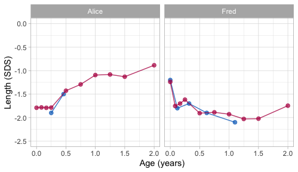

Alice and Fred - observed (blue) and fitted (red) trajectory.

```r
plot(fit9, newdata = data, ylim = c(-2.5, 0),
     xlab = "Age (years)", ylab = "Length (SDS)")
```

Alice contributes only two data points in the first half-year. The model expects that her height SDS will be around -1 SD at the age of two years. Using the data up to 1.1 years, the model predicts that Fred’s growth curve remains around -2.0 SD until Fred is 1.5 years, and then increases to around -1.8 SD. While both predicted trajectories are extreme extrapolations, the example illustrates that it is possible to make informed predictions using just a handful of data points.

The `brokenstick:::EB()` function implements the empirical Bayes (EB) estimate, also known as BLUP (Skrondal and Rabe‐Hesketh (2009), p. 683). The procedure is the workhorse underlying the `predict()` method.

## Quality of prediction

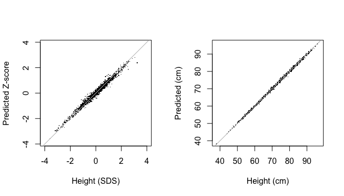

Predicted versus observed values.

Figure 9 is the scatterplot of the observed versus predicted values provides a visual representation of the accuracy of the prediction of the model in height SDS and cm scales. Both plots suggest an excellent fit between the observed and fitted data. The percentage of explained variance for the height SDS is high: 97.8%. The standard deviation of the residuals is equal to 0.152 SD, a small value in the $Z$-scale. When back-converted to centimetres, the scatterplot of the observed versus predicted values is even a little tighter. The proportion of explained variance is close to perfection: 99.9%. The standard deviation of the residuals is 4 mm, about the size of the technical error of measurement (TEM) for duplicate measurements in infants.(Ismail et al. 2016, Table 2)

The model is as good as it can get. The uncertainties associated with the transformation from varying observation times to repeated measures will be small. For all practical purposes, the results from a linear mixed or multilevel model and a repeated measures model are likely to be same.

## Knot placement strategies

Fitting the broken stick model requires a specification of the knots. The choice of the knots influences the quality and usefulness of the solution, so exercise some care in setting appropriate knot locations.

The `brokenstick()` function uses the same set of knots for all subjects. By default, the procedure places the boundary knots at the range of the data and no inner knots, resulting in a model that is linear in time without breakpoints. The `k` argument is a quick way to add `k` internal knots at equidense quantiles of the time variable. For example, specifying `k = 1` puts a knot at the 50th quantile (median), setting `k = 3` puts knots at the 25th, 50th and 75th quantiles, and so on. While convenient and quick, this option can result in suboptimal knot placement that is not adequate for the problem at hand. In general, it is best to specify explicit values for the `knots` and `boundary` arguments.

Here are some suggestions for knot placement:

1. Rule of thumb: Limit the number of knots to the (average) number of data points per subject;
2. If you want to predict at specific ages, then specify knots at those ages. For example, if the scientific interest includes prediction at the age of 1 and 2 years, then include these ages as knots;
3. Setting knots at scheduled visits is a sensible strategy for obtaining predictions at precisely the scheduled times. Set equidistant knots if the analysis requires a fixed time interval;
4. Keep the number of knots low, for speed and simplicity. Having many ($\geq 10$) knots can improve the fit to the data. Still, it will also increase calculation time and may result in unstable solutions. For problems that require more than 10 knots, reduce calculation time by the setting `method = "kr"` method, and use `control_kr()` to improve stability by a correlation model;
5. Do not place knots in sparsely filled areas of the data, e.g. in-between two visits. Doing so may result in erratic joins;
6. Define a starting time common to all subjects (e.g. birth) and set the first breakpoint `knots[1]` equal to the left boundary knot `boundary[1]`. The `brokenstick()` is already cautions to ensure this;
7. Order knots in size;
8. Use the `get_knots()` function to extract knots from a fitted model;
9. Set maximum value in `knots` to the highest time of scientific interest, but still within the data range. Set boundary knot `boundary[2]` larger than this value, e.g. equal to the maximum of the time variable. Broken stick estimates at the right boundary knot have no useful interpretation, so exclude those estimates from plots and ignore them in subsequent analyses;
10. Set knots to explicit values to support generalisation over the time variable in the training data.

# Applications

## Critical periods

The following question motivated the development of the broken stick model: *At what ages do children become overweight?* Knowing the answer to this question provides handles for preventive interventions to counter obesity. Dietz (1994) suggested the existence of three critical periods for obesity at adult age: the prenatal period, the period of adiposity rebound (roughly around the age of 5-6 years), and adolescence. Obesity formed in these periods is likely to increase the obesity risk at adult age and its complications.

A growth period, bounded by ages $T_1$ and $T_2$, is critical for adult overweight if the following criteria hold: (de Kroon et al. 2010)

1. there is a significant difference in mean gain score $Z_2-Z_1$ between subjects with and without adult overweight;
2. the gain score $Z_2-Z_1$ has an independent contribution over $Z_2$ to the prediction of $Z_{\rm adult}$. It not only matters where you were at $T_2$ but also how you got there;
3. $Z_2$ correlates highly with $Z_{\rm adult}$, so it is easier (i.e. with higher sensitivity and specificity) to identify children at risk for adult overweight.

de Kroon et al. (2010) found that the age interval 2-6 years met all criteria for a critical period. Our re-analysis tests the requirements for the following age intervals: birth-4 months, 4 months-1 year, 1-2 years, 2-4 years, 4-6 years, 6-10 years and 10-14 years. Hence, we define the following break ages:

```r
knots <- round(c(0, 1/3, 1, 2, 4, 6, 10, 14, 24, 29), 3)
labels <- c("birth", "4m", "1y", "2y", "4y", "6y", "10y", "14y", "24y", "")
```

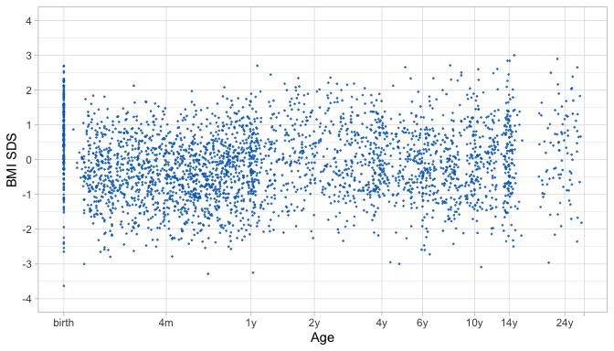

Body Mass Index (BMI) SDS by log(age + 0.2) (Terneuzen cohort)

The Terneuzen Birth Cohort (de Kroon et al. 2008) comprises of 2604 children born around the year 1980 in Terneuzen, The Netherlands. Figure 10 shows the BMI standard deviation scores (SDS) against age in a random subset of 306 children. While we may easily recognise scheduled visits at birth, 1y and 14y, observations at other periods are less structured. Compared to the analysis in de Kroon et al. (2010), we removed the knots at 8 days and 18 years (because these appear in sparse data areas) and added knots at 4, 14 and 24 years. We set the right boundary knot to 29y, slightly higher than the maximum age in the data.

```r
ctl <- lmerControl(check.conv.grad = .makeCC("warning", 0.02, NULL),
                   check.conv.singular = .makeCC("ignore", 0.001))
fit_lmer <- brokenstick(bmi.z ~ age | id, data = mice::tbc,
                        knots = knots, boundary = c(0, 29),
                        method = "lmer", control = ctl)
```

The control specification prevents warnings and messages that result from the over-parametrised nature of the model.

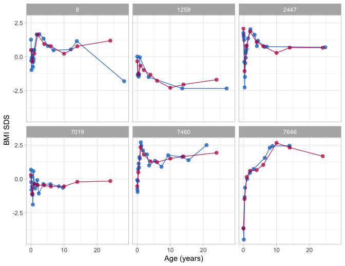

Body Mass Index (BMI) SDS trajectories of six subjects, observed (blue) and fitted (red). lmer method.

```r
ids <- c(8, 1259, 2447, 7019, 7460, 7646)
plot(fit_lmer, group = ids,
     ylab = "BMI SDS", xlab = "Age (years)")
```

Figure 11 shows observed and fitted BMI SDS trajectories for six subjects using the `lmer` method. In general, the model fits the data well. The per cent explained variance of BMI SDS obtained by `get_r2(fit_lmer)` equals 84 per cent. Note that he fitted trajectory for subject 8 reveals a pretty rough estimate at the age of 24y. Persons 1259 and 7460 have very low (-2.5 SD) and high (+2.5 SD) BMI SDS at adult age, respectively. Note that the model pulls the adult BMI SDS estimates (in red) towards the global mean, due to the well-known bias-variance tradeoff.(Gelman and Hill 2007, 394) Pulling is more vigorous at the extremes. The effect is negligible for more average trajectories, such as for subject 2447.

One may stabilise the model by constraining the variance-covariance matrix, for example by the Argyle correlation model. As a result, the fitted trajectories will be much stabler in regions with sparse data. The following snippet applies the Argyle model.

```r
fit_kr <- brokenstick(bmi.z ~ age | id, data = mice::tbc,
                      knots = knots, boundary = c(0, 29),
                      seed = 41441, cormodel = "argyle")
```

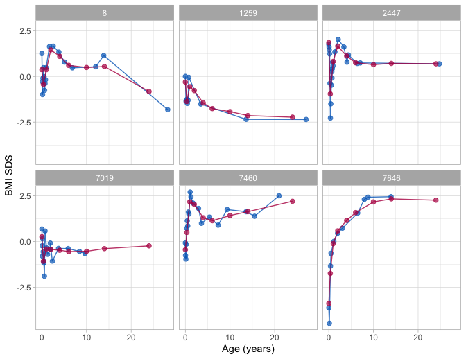

Body Mass Index (BMI) SDS trajectories of six subjects, observed (blue) and fitted (red). Argyle correlation model.

Figure 12 is the equivalent to Figure 11, but with the Argyle correlation model. The per cent explained variance is the same. Due to the constraint placed on the covariance matrix, the trajectories are slightly smoother and more stable in the adult ages with limited data. The rough estimate for subject 8 has gone. There is still some gravity towards to global mean at knot 24y for persons 1259 and 7460, but it is of lesser magnitude. All fitted trajectories are well behaved. We, therefore, select the `kr` solution for further analysis.

To identify critical periods, we need to predict adult overweight. In Figure 12, only three out of six subjects had a BMI measurement at adult age. Since we do not want the results to overly depend on fitted extrapolations, we restrict the analysis sample to persons with an adult measurement. The following lines extract the repeated measures for 92 (out of 306) individuals for whom we observed adult BMI.

```r
tbc1 <- mice::tbc %>%
  filter(!is.na(ao) & first) %>%
  select(id, nocc, sex)
tbc2 <- mice::tbc.target %>%
  filter(id %in% tbc1$id)
prd <- predict(fit_kr, mice::tbc, x = "knots",
               shape = "wide", group = tbc1$id)
data <- bind_cols(prd,
                  select(tbc1, -id),
                  select(tbc2, -id))
head(data, 3)
```

```
## # A tibble: 3 × 15
##      id   `0` `0.333`     `1`    `2`    `4`    `6`   `10`   `14`   `24`   `29`
##   <dbl> <dbl>   <dbl>   <dbl>  <dbl>  <dbl>  <dbl>  <dbl>  <dbl>  <dbl>  <dbl>
## 1     8 0.371  -0.439  0.366   1.45   1.10   0.606  0.489  0.542 -0.825 -1.18
## 2    60 0.159  -0.372 -0.0443 -0.360 -0.595 -0.819 -1.03  -1.16  -1.46  -1.39
## 3    97 1.68    0.569  0.948   1.90   1.28   0.838  0.444  0.239  0.397  0.708
## # … with 4 more variables: nocc <dbl>, sex <dbl>, ao <dbl>, bmi.z.jv <dbl>
```

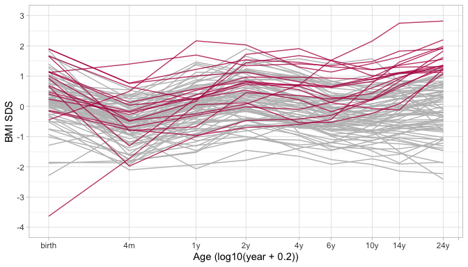

Body Mass Index (BMI) SDS trajectories for 92 subjects, coloured by adult overweight status.

Figure 13 shows the 92 fitted trajectories coloured by adult overweight status (BMI SDS > 1.3). It is evident that BMI SDS at ages of 14y or 10y is highly predictive of adult overweight, but does that also hold in early childhood? Also, does a change in specific periods predict later overweight? To answer such questions, we fit simple linear models to predict observed (not fitted!) BMI SDS at adult age from the fitted BMI SDS trajectories. The following code block fits two models for the period 4y-6y.

```r
m1 <- lm(bmi.z.jv ~ `6`, data)
m2 <- lm(bmi.z.jv ~ `6` + I(`6`-`4`), data)
anova(m1, m2)
```

```
## Analysis of Variance Table
##
## Model 1: bmi.z.jv ~ `6`
## Model 2: bmi.z.jv ~ `6` + I(`6` - `4`)
##   Res.Df  RSS Df Sum of Sq    F  Pr(>F)
## 1     90 74.3
## 2     89 63.4  1      10.8 15.2 0.00019 ***
## ---
## Signif. codes:  0 '***' 0.001 '**' 0.01 '*' 0.05 '.' 0.1 ' ' 1
```

## Time-to-time correlations

The *conditional gain score* is defined as (T. J. Cole 1995)

$${\rm conditional}\ Z_{\rm gain} = \frac{Z_2 - rZ_1}{\sqrt{1-r^2}},$$

where $Z_1$ and $Z_2$ are the standard deviation scores at times $T_1$ and $T_2$, with $T_2>T_1$, and where $r$ is the correlation between $Z_1$ and $Z_2$. The conditional gain corrects for regression to the mean, which is its selling point over traditional velocity measures and is less sensitive to measurement error.(van Buuren 2007) A practical difficulty is to obtain $r$ for a given $T_1$ and $T_2$. The time-to-time correlation matrix needs to be known. Also, we need to interpolate $r$ if $T_1$ or $T_2$ differs from the tabulated ages.

```r
fit <- brokenstick(hgt_z ~ age | id, data = smocc_200,
                   knots = 1:4/2, boundary = c(0, 3))
omega <- get_omega(fit)
t2t <- omega + diag(fit$sigma2, ncol(omega))
round(cov2cor(t2t), 2)
```

```
##         age_0 age_0.5 age_1 age_1.5 age_2
## age_0    1.00    0.56  0.44    0.36  0.32
## age_0.5  0.56    1.00  0.76    0.70  0.65
## age_1    0.44    0.76  1.00    0.80  0.77
## age_1.5  0.36    0.70  0.80    1.00  0.81
## age_2    0.32    0.65  0.77    0.81  1.00
```

```r
fit <- brokenstick(hgt_z ~ age | id, data = smocc_200,
                   knots = seq(0, 2, 0.1), boundary = c(0, 3),
                   cormodel = "argyle")
omega <- get_omega(fit)
t2t <- omega + diag(fit$sigma2, ncol(omega))
dim(t2t)
```

```
## [1] 21 21
```

We cannot indefinitely add breakpoints. Suppose we double the number of knots by setting `knots = seq(0, 2, 0.05)`. Then even `kr` is not able to cope and will abort with `Error: Sigma is symmetric but not positive`. Thus, as always, be sensible in what you ask the software to do for you.

## Profile analysis

Profile analysis (Morrison 1976; Johnson and Wichern 1988) refers linear multivariate linear methods to test for differences in population means or treatment effects, typically by regression analysis or multivariate analysis of variance (MANOVA). These methods assume independence of subjects, organise the data at the subject level, and express parameters of interest by linear combinations of outcomes, like change scores, means or other derived quantities.

Krone et al. (2020) report a statistical analyses using the linear mixed model with time-varying individual subject data. This section re-analyses the data from Figure 4 using the broken stick model. The data are available as the `brokenstick::weightloss` object.

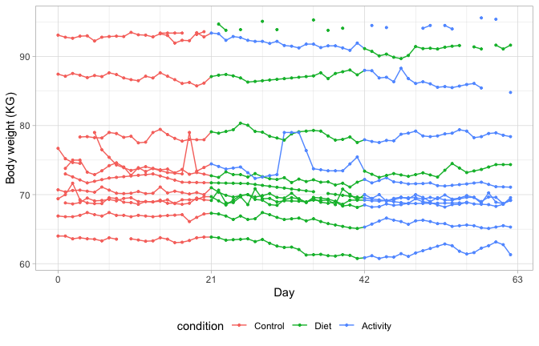

Daily body weight (KG) for 12 subjects under three conditions.

Figure 14 charts daily body weight measurements of twelve individuals who were followed for nine weeks. The investigators subdivided the total duration into three periods of three weeks. Period one (week 1-3) acted as a control period. During period 2 (week 4-6), the investigators stimulated participants to restrict food intake, and during period 3 (week 7-9) the experimenters promoted physical activity. Subjects 4 and 12 received the interventions in the opposite order. See Krone et al. (2020) for more detail.

Most of these subjects adhere quite well to the data collection design. Some trajectories show gaps due to missed measurements. The most extreme example is the trajectory at the top, which has only scant measures. Other curves display stretches of lines, suggesting that missed measurements were linearly interpolated. One of the series shows some surprising spikes, likely to be measurement errors. All in all, these data perfectly illustrate the inescapable imperfections of real data.

The remainder of the section discusses two ways to estimate the effect of diet and physical activity on body weight.

### Constant model

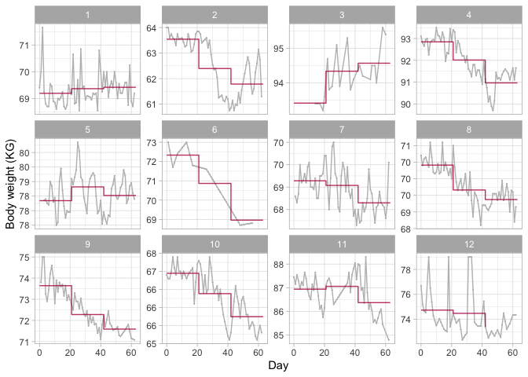

Constant model. Observed and fitted trajectories for a model that summarises each experimental period by a constant.

```r
fit0 <- brokenstick(body_weight ~ day | subject, data,
                    knots = c(0, 21, 42, 63), degree = 0)
plot(fit0, size_y = 0, color_y = rep("grey", 2), what = "all",
     scales = "free_y", xlab = "Day", ylab = "Body weight (KG)",
     n_plot = 12, ncol = 4)
```

The model underlying Figure 15 summarises the trajectory within a period by a constant, the mean. We obtain an estimate of these mean by setting the `degree = 0` argument. This model gives a fair representation of the trajectory of subjects 9 (a persistent downward trend), 1 and 5 (no trend). On the other hand, the model fails to capture patterns for subjects 2, 4 and 8 (rebound in period 3) or 11 (inverse rebound).

It is straightforward quantify the effects of `Diet` and `Activity` relative to `Control`. The next code snippet calculates these effects per person, accounting for the intervention order reversal for subjects 4 and 12.

```r
prd <- data.frame(predict(fit0, data, x = "knots", shape = "wide"))
control <- prd[, 2]
diet <- prd[, 3]
diet[c(4, 12)] <- prd[c(4, 12), 4]
activity <- prd[, 4]
activity[c(4, 12)] <- prd[c(4, 12), 3]
round(data.frame(diet_control = diet - control,
                 activity_control = activity - control,
                 activity_diet = activity - diet), 1)
```

```
##    diet_control activity_control activity_diet
## 1           0.2              0.2           0.1
## 2          -1.1             -1.8          -0.6
## 3           0.9              1.2           0.2
## 4          -1.9             -0.8           1.0
## 5           0.5              0.2          -0.3
## 6          -1.5             -3.4          -1.9
## 7          -0.1             -0.5          -0.4
## 8          -0.7             -1.0          -0.3
## 9          -1.4             -2.1          -0.7
## 10         -0.6             -1.2          -0.6
## 11          0.1             -0.6          -0.7
## 12         -1.3             -0.3           1.1
```

### Broken stick model

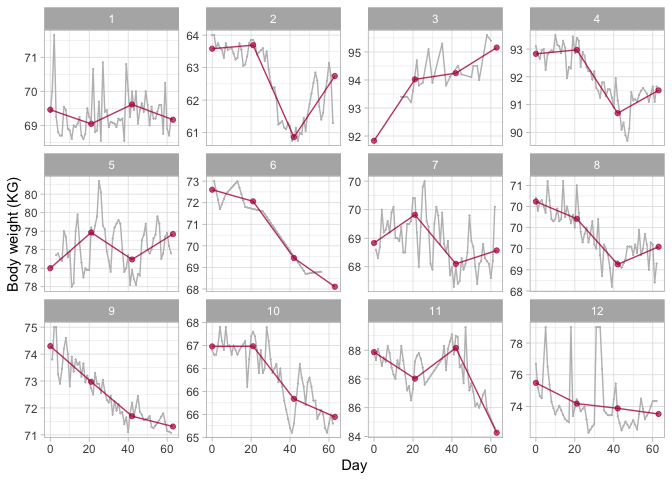

Broken stick model. Observed and fitted trajectories for a model that summarises each experimental period by a line.

```r
fit1 <- brokenstick(body_weight ~ day | subject, data,
                    knots = c(0, 21, 42, 63))
plot(fit1, size_y = 0, color_y = rep("grey", 2), what = "all",
     size_yhat = 1.5, scales = "free_y", , xlab = "Day", ylab = "Body weight (KG)",
     n_plot = 12, ncol = 4)
```

Figure 16 shows the same data as in Figure 15 but now fitted by the broken stick model. This model also suggests a persistent downward trend for subject 9 and an absence of for participants 1 and 5. Also, the model now correctly identifies the prominent zig-zag patterns for persons 2, 4, 8 and 11 across the three experimental periods.

```r
prd <- data.frame(predict(fit1, data, x = "knots", shape = "wide"))
control <- prd[, 3] - prd[, 2]
diet <- prd[, 4] - prd[, 3]
diet[c(4, 12)] <- prd[c(4, 12), 5] - prd[c(4, 12), 4]
activity <- prd[, 5] - prd[, 4]
activity[c(4, 12)] <- prd[c(4, 12), 4] - prd[c(4, 12), 3]
round(data.frame(control = control,
                 diet = diet,
                 activity = activity), 1)
```

```
##    control diet activity
## 1     -0.4  0.6     -0.4
## 2      0.1 -2.8      1.9
## 3      2.2  0.2      0.9
## 4      0.1  0.8     -2.3
## 5      1.0 -0.7      0.7
## 6     -0.5 -2.6     -1.3
## 7      0.5 -0.9      0.2
## 8     -0.4 -1.1      0.4
## 9     -1.3 -1.3     -0.4
## 10     0.0 -1.1     -0.4
## 11    -0.9  1.1     -2.9
## 12    -1.3 -0.4     -0.3
```

We may obtain a simple estimate of the sequence effect by linear regression as

```r
df <- data.frame(y = c(diet, activity),
                 act = rep(c(0, 1), each = 12),
                 per2 = rep(c(rep(1, 3), 0, rep(1, 7), 0), 2))
coef(lm(y ~ act, data = df))
```

```
## (Intercept)         act
##       -0.69        0.36
```

```r
coef(lm(y ~ act + per2, data = df))
```

```
## (Intercept)         act        per2
##      -0.706       0.356       0.024
```

This application demonstrates that the broken stick model can effectively capture rapid linear changes in experiments. Even though the actual timing of the observations may be erratic, it is easy to define, interpret and calculate intuitive effect estimates at the individual level. Note that the analysis here assumed an instantaneous effect of the interventions. If we expect a delay, then we may right-shift the knots by a few days and re-estimate the broken stick model. By varying the number of days, we may be able to detect the optimal delay factor.

## Curve interpolation

### Problem

A growth chart visualises the individual trajectory relative to a set of centile lines. We may store a centile line as a set of coordinates with a relatively dense age grid. If we connect the adjacent vertices by a straight line, the centile will appear as smooth in time. However, this plotting method runs into trouble when ages are wide apart. This section shows how we can create a realistic interpolation with sparse time data.

### Interpolation in measurement scale

Suppose we measured the length of a boy at the ages of 1 month (52.6 cm) and 14 months (81.7 cm). The following code block uses the `AGD::y2z()` function to convert the measurements to standard deviation scores (SDS) relative to the reference of the Fourth Dutch Growth Study.

```r
boy <- data.frame(x = c(1/12, 14/12), y = c(52.6, 81.7))
ref <- AGD::nl4.hgt
boy$z <- AGD::y2z(y = boy$y, x = boy$x, sex = "M", ref = ref)
boy$z
```

```
## [1] -0.98  0.99
```

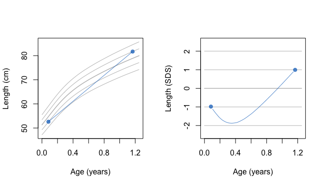

Linear interpolation in the cm scale results in an unrealistic trajectory at intermediate ages.

During the period the boy grows from moderately short (about -1.0 SD at month 1) to relatively tall (about +1.0 SD at month 14). Figure 17 shows the usual representation of the growth chart with a straight line drawn between the two values. Due to the convex shape of the centile lines, the straight line that connects the two measurements starts at -1.0 SD, then touches the -2.0 SD centile around 0.3 yr, is back at -1.0 SD around 0.7 yr, crosses the 0.0 SD line at 1 yr, and ends at +1.0 SD at 1.2 yr. The graph on the right-hand side portrays the interpolated growth curve in the $Z$-score scale. Since length growth during infancy is not linear in time, finding a real growth curve like this is extremely unlikely. Since we have just two data points smoothing the data does not help either.

### Interpolation in the Z-score scale

A first alternative is to apply the linear interpolation in the $Z$-score scale. This option is attractive because convexity of centile lines is absent on this scale.

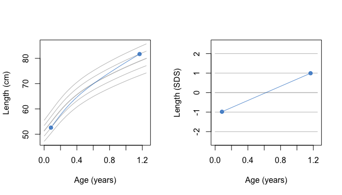

Linear interpolation in the Z-score scale results in a more realistic trajectory at intermediate ages.

Figure 18 illustrates the interpolation in the $Z$-scale. By definition, the line that connects the measurements is straight in the $Z$-score scale. In the cm scale, the representation is more realistic and more pleasing to the eye. The curve crosses the 0 SD line about halfway, at about 0.6 yr.

While this approach is a considerable improvement over interpolation in the $Y$-scale, it is still not ideal. The assumption underlying this interpolation is that the $Z$-score increment is constant across time. This assumption is false, however. Since length growth is more variable during the first half-year than in the second half-year, we expect that the larger share of the increment to occur during the earlier months. In other words, the cross-over point at 0.6 yr is too late.

### Interpolation by the broken stick model

The second alternative is a model-based interpolation. Assuming the availability of a fitted broken stick model, we specify a dense time grid, say every week, and predict the length at these times given the data from the observed trajectory. The expected curve represents the most likely values under the model at the intermediate ages. The following code calculates the relevant estimates from the `fit_200` fitted model:

```r
# prepare data input
age <- round(seq(2/24, 28/24, 1/24), 3)
z <- rep(NA, length(age))
z[1] <- boy$z[1]; z[length(z)] <- boy$z[2]

# predict with broken stick model
zout <- predict(fit_200, x = age, y = z, shape = "vector")

# convert predicted values to Y-scale
yout <- AGD::z2y(x = age, z = zout, ref = ref)
```

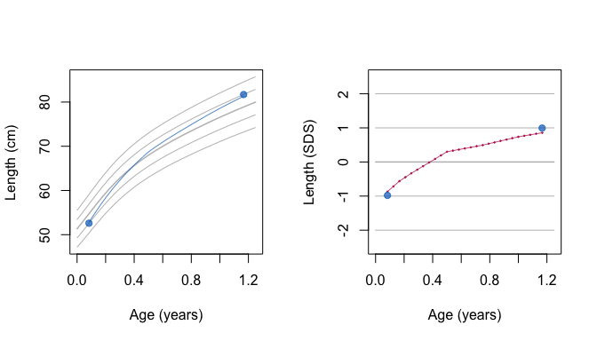

Broken stick model fitted in the SDS scale results in a most realistic expected trajectory at intermediate ages.

Figure 19 shows the results of the broken stick model. The predicted curve in the $Y$-scale represents the most likely course according to the broken stick model. Because growth is more variable during early infancy, the child realises the larger share of the change during the first part of the period. As a result, the cross-over point where the predicted value intersects the 0 SD line is now at 0.4 yr, considerably earlier than obtained by the two other interpolation methods. The plot on the right-hand side confirms the steeper slope in the first part. Note that this method treats rising and declining curves alike. For example, if the boy’s length would be 57 cm at month 1 (+1.0 SD) and 76 cm at month 14 (-1.0 SD), the cross-over point would also be at 0.4 yr.

Observe that we left the world of pure interpolation and moved to an approximation of the data by a model. The observed and predicted lengths are not exactly equal. The difference is so small that we may hardly notice the discrepancy when plotted in the $Y$-scale, but it is more conspicuous in the $Z$-score scale. Of the three approaches considered here, the broken stick model provides the most realistic expected trajectory at the intermediate ages.

## Multiple imputation

Remember from section 2 that the broken stick estimates are conditional means. We may be tempted to analyse these estimates as if they were “just data,” but they do not have the same variability as the real data. For example, suppose we calculate the correlation matrix of the broken stick estimates. We know that the values in this matrix will exceed those from the underlying observed data. Not accounting for this fact leads to overconfident predictions and results that are too good to be true.

Multiple imputation (Rubin 1987; van Buuren 2018b) restores variability by adding noise. We may fit standard complete-data software to the imputed data, and obtain valid regression weights, confidence intervals and $P$-values under a wide range of conditions.

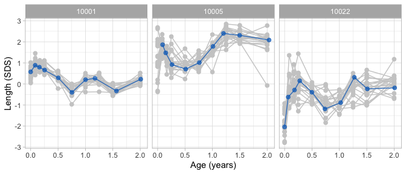

Observed data plotted on top of 20 imputed trajectories.

```r
knots <- round(c(0, 1, 2, 3, 6, 9, 12, 15, 18, 24)/12, 4)
data <- bind_rows(smocc_200[!is.na(smocc_200$hgt_z), ],
                  expand.grid(id = unique(smocc_200$id), age = knots))
fit_kr <- brokenstick(hgt_z ~ age | id, data = data,
                      knots = knots, boundary = c(0, 3),
                      nimp = 20, seed = 15244)
plot(fit_kr, show = c(TRUE, FALSE, TRUE),
     group = c(10001, 10005, 10022),
     xlab = "Age (years)", ylab = "Length (SDS)")
```

Figure 20 displays the observed data from three persons plotted on top of 20 imputed trajectories. The within-person within-time average over the grey trajectories approximates to the broken stick estimate (not shown here). The observed curve in each panel occasionally strays towards the boundaries of the grey bundle. This behaviour is as expected and indicates that the blue curve performs like a grey curve.

Section 5.2 showed how we can estimate the time-to-time correlation matrix. An alternative way is to calculate it from the imputed data, as follows:

```r
expand.grid(id = unique(smocc_200$id), age = knots) %>%
  bind_cols(as.data.frame(fit_kr$imp)) %>%
  pivot_longer(cols = num_range("", 1:fit_kr$control$nimp), names_to = "imp") %>%
  pivot_wider(id_cols = c("id", "imp"), names_from = "age") %>%
  select(-id, -imp) %>%
  cor() %>%
  round(2)
```

```
##           0 0.0833 0.1667 0.25  0.5 0.75    1 1.25  1.5    2
## 0      1.00   0.69   0.69 0.62 0.45 0.43 0.37 0.31 0.32 0.26
## 0.0833 0.69   1.00   0.80 0.79 0.66 0.56 0.51 0.52 0.49 0.41
## 0.1667 0.69   0.80   1.00 0.82 0.70 0.59 0.52 0.51 0.53 0.47
## 0.25   0.62   0.79   0.82 1.00 0.75 0.64 0.58 0.55 0.55 0.51
## 0.5    0.45   0.66   0.70 0.75 1.00 0.84 0.82 0.72 0.75 0.68
## 0.75   0.43   0.56   0.59 0.64 0.84 1.00 0.84 0.76 0.75 0.70
## 1      0.37   0.51   0.52 0.58 0.82 0.84 1.00 0.83 0.81 0.76
## 1.25   0.31   0.52   0.51 0.55 0.72 0.76 0.83 1.00 0.84 0.82
## 1.5    0.32   0.49   0.53 0.55 0.75 0.75 0.81 0.84 1.00 0.84
## 2      0.26   0.41   0.47 0.51 0.68 0.70 0.76 0.82 0.84 1.00
```

Another important application of the multiply-imputed curves is to obtain correct confidence intervals and $P$-values for estimates of scientific interest. The most convenient way to do this is to convert the `brokenstick` object into an object of class `mids`, as defined by the **mice** package. The **brokenstick** package currently has no features that perform the conversion.

## Curve matching

Curve matching (van Buuren 2014) is a tool to assist in the interpretation and prediction of individual growth curves. The idea is as follows. Suppose we measure the growth of the target child up to half a year and plot the measurements onto his or her growth chart. Curve matching is a nearest-neighbour technique that relies on historical growth data. It finds, say, ten other children who are similar to the target child, and add the curves of those matches to the child’s chart. If the matching is done right, then the bundle of historic growth curves suggests how the target child will develop in the future.

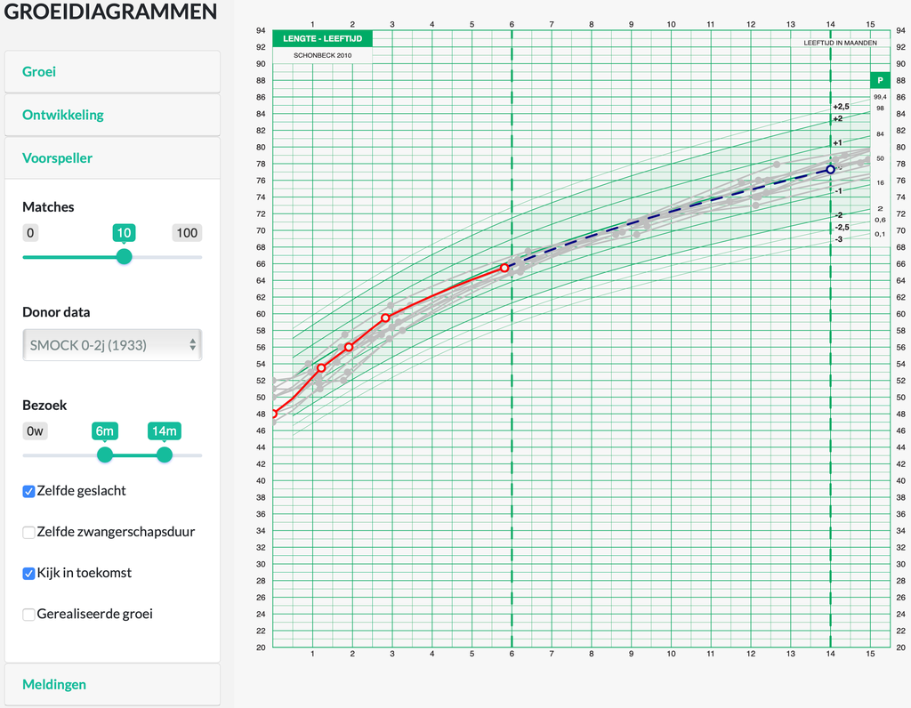

Curve matching. Predict infant length at 14 months given length data up to 6 months using 10 matches.

Figure 21 demonstrates curve matching for infant length. The red curve corresponds to five measurements of the target child made during the first six months. The ten grey curves are historic growth curves from the ten matched children. We may define similarity in many ways. Here we use a linear model to predict length at the age of 14m from previous length data. The distance between the target child and another child is equal to the difference between their predicted values. The procedure lifts the data of the matches from the database, and plots the observed growth curves onto the chart as grey curves. This method for finding nearest neighbours is known as *predictive mean matching* and has grown into a powerful technique for missing data.(van Buuren 2018b) The bundle of grey curves indicates some possible future trajectories of the target child. The mean of the bundle is the most likely path. Graphically it is the dotted blue curve between the last measurement and the age of the outcome.

Let’s look at a numerical example. We split the data into one target child and 199 donor children, and fit a broken stick model to the donor set.

```r
donor_data <- smocc_200 %>%
  filter(id != "10001")
target_data <- smocc_200 %>%
  filter(id == "10001" & age < 0.51)

# fit brokenstick model at time level
knots <- round(c(0, 1, 2, 3, 6, 9, 12, 15, 18, 24)/12, 4)
fit <- brokenstick(hgt_z ~ age | id, data = donor_data,
                   knots = knots, boundary = c(0, 3),
                   seed = 15244)
```

All timepoints from the donor data enter the broken stick model. Note that the `target_data` contains only observations from the first five visits.

We now fit the prediction model on the child-level donor data. The prediction model contains the broken stick estimates for length SDS up to 6 months, as well as sex, gestational age and birth weight as covariates.

```r
# predict with matching model at child level
covariates <- donor_data %>%
  group_by(id) %>%
  slice(1)
bse <- predict(fit, donor_data, x = "knots", shape = "wide")
donors <- bind_cols(covariates, select(bse, -id))
model <- lm(`1.25` ~ `0` + `0.0833` + `0.1667` + `0.25` + `0.5`
            + sex + ga + bw, data = donors)
summary(model)
```

```
##
## Call:
## lm(formula = `1.25` ~ `0` + `0.0833` + `0.1667` + `0.25` + `0.5` +
##     sex + ga + bw, data = donors)
##
## Residuals:
##     Min      1Q  Median      3Q     Max
## -1.3322 -0.2566 -0.0146  0.2637  1.4648
##
## Coefficients:
##              Estimate Std. Error t value Pr(>|t|)
## (Intercept)  4.86e-01   8.99e-01    0.54    0.589
## `0`          6.75e-02   5.32e-02    1.27    0.206
## `0.0833`     5.92e-02   8.69e-02    0.68    0.496
## `0.1667`    -2.56e-01   9.92e-02   -2.58    0.011 *
## `0.25`      -2.16e-01   1.07e-01   -2.01    0.046 *
## `0.5`        1.21e+00   7.54e-02   16.07   <2e-16 ***
## sexmale      9.12e-02   6.42e-02    1.42    0.157
## ga          -7.04e-03   2.25e-02   -0.31    0.755
## bw          -7.54e-05   1.09e-04   -0.69    0.490
## ---
## Signif. codes:  0 '***' 0.001 '**' 0.01 '*' 0.05 '.' 0.1 ' ' 1
##
## Residual standard error: 0.43 on 190 degrees of freedom
## Multiple R-squared:  0.777,  Adjusted R-squared:  0.767
## F-statistic: 82.6 on 8 and 190 DF,  p-value: <2e-16
```

The next step is to extract model predictions for both donors and target and find the ten closest donors.

```r
donors_pred <- predict(model)
names(donors_pred) <- donors$id

target <- bind_cols(
  slice(target_data, 1),
  select(predict(fit, target_data, x = "knots", shape = "wide"), -id))
target_pred <- predict(model, newdata = target)

matches <- sort(abs(donors_pred - target_pred))[1:10]
matches
```

```
##  11013  10032  11035  10093  10051  11063  11086  11083  11102  11049
## 0.0041 0.0062 0.0181 0.0188 0.0253 0.0266 0.0310 0.0375 0.0509 0.0592
```

Finally, let us study the observed and fitted trajectories of the ten matches.

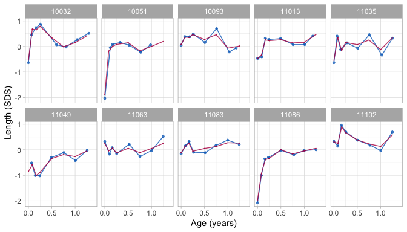

Curve matching. Observed and fitted trajectories of 10 matches for subject 10001.

```r
ids <- as.numeric(names(matches))
plot(fit, group = ids,
     xlim = c(0, 1.4), size_y = 1, size_yhat = 0,
     xlab = "Age (years)", ylab = "Length (SDS)",
     ncol = 5)
```

If we wish the curves of the matches during the first six months to be closer to the target case, we could consider alternative metrics. A simple measure is the sum of squares differences of the broken stick estimates. Such a selection may be visually more pleasing, at the expense of prediction accuracy. On the other hand, we are less tied to setting one particular future time point, so other measures may work better when “future” is more vaguely defined as a time interval. It is still an open research question where we strike a balance. Whatever the objectives of preferences from the user might be, the curve matching methodology, as illustrated here, has tremendous flexibility and is easy to adapt.

# Conclusion

### Overview

This paper introduces a new approach to solve the problem of irregular longitudinal data. The method absorbs the time-dependent information into a set of broken stick estimates at the subject level. The primary advantage is that it simplifies the analysis by splitting the modelling problem into two steps. First, solve the timing problem, and then solve the substantive/scientific problem. The method is mathematically simple, using a linear B-spline, conceptually simple, yet principled.

### Distinctive features

The assumptions of the model cover many cases of practical interest: a straight line between breakpoints, a multivariate normal distribution for the random effects, and the MAR assumption including future data. Despite the relatively low number of model parameters, it is possible to obtain a close fit to the data, sometimes almost up to perfect reconstruction (c.f. Figure 9). There is no need to specify equidistant breakpoints. Applications in human growth and development are often more natural using non-uniformly spaced knots, which is very easy to model. Many people find it easier to understand the raw data values than the summaries. The broken stick model invites visualisation of the actual data points against time and makes it is easy to portray uncertainty as a bundle of curves. Such direct visualisation options contribute to the explainable and responsible personalised analyses that appeal to a broad user group.

### Current limitations

The broken stick model, as presented here, uses just three variables: time, measurement and group. This design choice simplifies interpretation and estimation. The lack of covariates in the model implies that the transformation from irregular data to repeated measures is identical for every subject. As long as the residual error is small, the relations with not-in-the-model variables thus remain intact. The possibility to include covariate in a second-round enhances modular modern analytic pipelines. Yet, some will prefer the direct estimation of all effects in one more extensive analysis. The current package does not support covariates. However, an experienced `R` user will have no difficulty in extending the formula in section 3.5 to include the covariates of interest.

The method that requires that all subject share the same time axis and breakpoints. In our applications, synchronisation at the start was most natural (e.g. birth, start of experiment), which is easy to do. In some cases, one might wish to anchor in the middle, e.g. at menarche, which occurs at different ages for different individuals.(Naumova, Must, and Laird 2001) It could also make sense to fasten the end, e.g. at death. However, it will be hard to do meaningful predictive analysis as we cannot anchor alive subjects. The choice of the anchor may matter less for cyclic processes. The broken stick model is not suited for applications where breakpoints vary between individuals. In those cases, it is better to use the linear mixed model directly.

### Software

The Kasim-Raudenbush sampler (Kasim and Raudenbush 1998) is both fast and flexible. It produces estimates of the residual error variance per subject, can accommodate for correlation models and supports multiple imputation out-of-the-box. More research needed to establish its statistical properties especially compared to `lmer()` and other established methods. It would also be interesting to study the suitability of the correlation models implemented in the **lme4qtl** package (Ziyatdinov et al. 2018). As no training data are stored, instances of the `brokenstick` model class are tiny, often 15–20k.

Features not implemented, but that could be useful in future versions include a separate `impute()` function that inputs class `brokenstick` and returns class `mids`, a Trelliscope (Hafen and Schloerke 2020) viewer to quickly peruse hundreds of individuals model fits, an extension to multivariate time-varying and child-level data, and a generalisation to `degree > 1` to support quadratic and cubic splines.

### Methodological advances

The primary modelling task for the user is to set the proper knot locations. One might envision scenarios where we want to search for the “best” places. It is not yet clear how we should do this, and how far we could automate knot placement strategies.

We need more insight into the statistical properties of procedures that execute the analysis as a sequence of steps. The relative pro’s and con’s of choices between multiple imputation versus random effects are not yet fully understood.

The current procedure assumes that the within-person error is constant across all time points. However, we might expect that observing more data close to the breakpoint will reduce the uncertainty of its estimate. In some applications, we might require that the estimate should equal the observed data value when the observation time coincides with the breakpoints. While models for such scenarios are considerably more complicated, they could also increase efficiency.

### Conclusion

This paper highlighted various applications of the broken stick model: critical periods, time-to-time correlation, profile analysis, curve interpolation, multiple imputation and personalised prediction. These applications certainly do not exhaust the potential of the model. My hope is that the availability of the software will stimulate creative uses, ideas and experiments.

# Literature

Akima, H., A. Gebhardt, T. Petzold, and M. Mächler. 2021. *akima: Interpolation of Irregularly and Regularly Spaced Data*. https://CRAN.R-project.org/package=akima.

Anderson, C., R. Hafen, O. Sofrygin, L. Ryan, and HBGDki Community. 2019. “Comparing Predictive Abilities of Longitudinal Child Growth Models.” *Statistics in Medicine* 38 (19): 3555–70.

Argyle, J., A. H. Seheult, and D. A. Wooff. 2008. “Correlation Models for Monitoring Child Growth.” *Statistics in Medicine* 27 (6): 888–904.

Bai, J., and P. Perron. 2003. “Computation and Analysis of Multiple Structural Change Models.” *Journal of Applied Econometrics* 18 (1): 1–22.

Bates, D., M. Mächler, B. Bolker, and S. Walker. 2015. “Fitting Linear Mixed-Effects Models Using lme4.” *Journal of Statistical Software* 67 (1): 1–48. https://doi.org/10.18637/jss.v067.i01.

Bellman, R., and R. Roth. 1969. “Curve Fitting by Segmented Straight Lines.” *Journal of the American Statistical Association* 64 (327): 1079–84.

Cole, T. 2021. *sitar: Super Imposition by Translation and Rotation Growth Curve Analysis*. https://CRAN.R-project.org/package=sitar.

Cole, T. J. 1995. “Conditional Reference Charts to Assess Weight Gain in British Infants.” *Archives of Disease in Childhood* 73 (1): 8–16.

de Boor, C. 1978. *A Practical Guide to Splines*. New York: Springer-Verlag.

de Kroon, M. L. A., C. M. Renders, E. C. Kuipers, J. P. van Wouwe, S. van Buuren, G. A. de Jonge, and R. A. Hirasing. 2008. “Identifying Metabolic Syndrome Without Blood Tests in Young Adults - the Terneuzen Birth Cohort.” *European Journal of Public Health* 18 (6): 656–60.

de Kroon, M. L. A., C. M. Renders, J. P. van Wouwe, S. van Buuren, and R. A. Hirasing. 2010. “The Terneuzen Birth Cohort: BMI Changes Between 2 and 6 Years Correlate Strongest with Adult Overweight.” *PloS ONE* 5 (2): e9155.

Dietz, W. H. 1994. “Critical Periods in Childhood for the Development of Obesity.” *American Journal of Clinical Nutrition* 59 (5): 955–59.

Diggle, P. J. 1988. “An Approach to the Analysis of Repeated Measurements.” *Biometrics*, 959–71.

Diggle, P. J., P. Heagerty, K. Y. Liang, and S. Zeger. 2002. *Analysis of Longitudinal Data. Second Edition.* Oxford: Oxford University Press.

Fitzmaurice, G. M, N. M. Laird, and J. H. Ware. 2011. *Applied Longitudinal Analysis. Second Edition.* New York: John Wiley & Sons.

Fredriks, A. M., S. van Buuren, R. J. F. Burgmeijer, J. F. Meulmeester, R. J. Beuker, E. Brugman, M. J. Roede, S. P. Verloove-Vanhorick, and J. M. Wit. 2000. “Continuing Positive Secular Growth Change in the Netherlands 1955-1997.” *Pediatric Research* 47 (3): 316–23.

Gelman, A., and J. Hill. 2007. *Data Analysis Using Regression and Multilevel/Hierarchical Models*. Cambridge: Cambridge University Press.

Hafen, R. 2021. *growthstandards: Anthropometric Growth Standard Calculations*. https://github.com/ki-tools/growthstandards.

Hafen, R., and B. Schloerke. 2020. *trelliscopejs: Create Interactive Trelliscope Displays*. https://CRAN.R-project.org/package=trelliscopejs.

Hand, D. J., and C. C. Taylor. 1987. *Multivariate Analysis of Variance and Repeated Measures: A Practical Approach for Behavioural Scientists*. Boca Raton, FL: CRC press.

Herngreen, W. P., S. van Buuren, J. C. van Wieringen, J. D. Reerink, S. P. Verloove-Vanhorick, and J. H. Ruys. 1994. “Growth in Length and Weight from Birth to 2 Years of a Representative Sample of Netherlands Children (Born in 1988-89) Related to Socio-Economic Status and Other Background Characteristics.” *Annals of Human Biology* 21 (5): 449–63.

Ismail, L. C., F. A. Puglia, E. O. Ohuma, S. T. Ash, D. C. Bishop, R. M. Carew, A. S. Al Dhaheri, and W. C. Chumlea. 2016. “Precision of Recumbent Crown-Heel Length When Using an Infantometer.” *BMC Pediatrics* 16 (1): 186.

Johnson, R. A., and D. W. Wichern. 1988. *Applied Multivariate Statistical Analysis. Second Edition.* Englewood Cliffs, NJ: Prentice Hall.

Kasim, R. M., and S. W. Raudenbush. 1998. “Application of Gibbs Sampling to Nested Variance Components Models with Heterogeneous Within-Group Variance.” *Journal of Educational and Behavioral Statistics* 23 (2): 93–116.

Kenward, M. G. 1987. “A Method for Comparing Profiles of Repeated Measurements.” *Journal of the Royal Statistical Society C (Applied Statistics)* 36 (3): 296–308.

Koenker, R., S. Portnoy, P. T. Ng, A. Zeileis, P. Grosjean, and B. D. Ripley. 2018. *quantreg: Quantile Regression*. https://CRAN.R-project.org/package=quantreg.

Koutsoyiannis, D. 2000. “Broken Line Smoothing: A Simple Method for Interpolating and Smoothing Data Series.” *Environmental Modelling & Software* 15 (2): 139–49.

Krone, T., R. Boessen, S. Bijlsma, R. van Stokkum, N. D. S. Clabbers, and W. J. Pasman. 2020. “The Possibilities of the Use of n-of-1 and Do-It-Yourself Trials in Nutritional Research.” *PloS ONE* 15 (5): e0232680.

Laird, N. M., and J. H. Ware. 1982. “Random-Effects Models for Longitudinal Data.” *Biometrics* 38 (4): 963–74.

Lepot, Mathieu, Jean-Baptiste Aubin, and François HLR Clemens. 2017. “Interpolation in Time Series: An Introductive Overview of Existing Methods, Their Performance Criteria and Uncertainty Assessment.” *Water* 9 (10): 796.

Lerman, P. M. 1980. “Fitting Segmented Regression Models by Grid Search.” *Journal of the Royal Statistical Society C (Applied Statistics)* 29 (1): 77–84.

Li, Jin, and Andrew D Heap. 2014. “Spatial Interpolation Methods Applied in the Environmental Sciences: A Review.” *Environmental Modelling & Software* 53: 173–89.

Lokku, A., L. S. Lim, C. S. Birken, E. M. Pullenayegum, and TARGet Kids! Collaboration,. 2020. “Summarizing the Extent of Visit Irregularity in Longitudinal Data.” *BMC Medical Research Methodology* 20: 1–9.

MacArthur, R. H. 1957. “On the Relative Abundance of Bird Species.” *Proceedings of the National Academy of Sciences of the United States of America* 43 (3): 293.

Morrison, D. F. 1976. *Multivariate Statistical Methods. Second Edition.* Singapore: McGraw-Hill.

Myatt, M., and E. Guevarra. 2019. *zscorer: Child Anthropometry z-Score Calculator*. https://CRAN.R-project.org/package=zscorer.

Naumova, E. N., A. Must, and N. M. Laird. 2001. “Tutorial in Biostatistics: Evaluating the Impact of ‘Critical Periods’ in Longitudinal Studies of Growth Using Piecewise Mixed Effects Models.” *International Journal of Epidemiology* 30: 1332–41.

Otto-Sobotka, F., E. Spiegel, S. Schnabel, L. Schulze Waltrup, P. Eilers, T. Kneib, and G. Kauermann. 2021. *expectreg: Expectile and Quantile Regression*. https://CRAN.R-project.org/package=expectreg.

Plummer, M., N. Best, K. Cowles, and K. Vines. 2006. “CODA: Convergence Diagnosis and Output Analysis for MCMC.” *R News* 6 (1): 7–11. https://journal.r-project.org/archive/.

Pullenayegum, E. M., and L. S. H. Lim. 2016. “Longitudinal Data Subject to Irregular Observation: A Review of Methods with a Focus on Visit Processes, Assumptions, and Study Design.” *Statistical Methods in Medical Research* 25 (6): 2992–3014.

R Core Team. 2020. *R: A Language and Environment for Statistical Computing*. Vienna, Austria: R Foundation for Statistical Computing. https://www.R-project.org/.

Ramsay, J. O., S. Graves, and G. Hooker. 2021. *fda: Functional Data Analysis*. https://CRAN.R-project.org/package=fda.

Rehfeld, K., N. Marwan, J. Heitzig, and J. Kurths. 2011. “Comparison of Correlation Analysis Techniques for Irregularly Sampled Time Series.” *Nonlinear Processes in Geophysics* 18 (3): 389–404.

Rubin, D. B. 1987. *Multiple Imputation for Nonresponse in Surveys*. New York: John Wiley & Sons.

Schumacher, D., E. Borghi, and J. Polonsky. 2020. *anthro: Computation of the WHO Child Growth Standards*. https://CRAN.R-project.org/package=anthro.

Skrondal, A., and S. Rabe‐Hesketh. 2009. “Prediction in Multilevel Generalized Linear Models.” *Journal of the Royal Statistical Society A (Statistics in Society)* 172 (3): 659–87.

Stasinopoulos, D. M., and R. A. Rigby. 2007. “Generalized Additive Models for Location Scale and Shape (GAMLSS) in r.” *Journal of Statistical Software* 23 (7): 1–46.

Toms, J. D., and M. L. Lesperance. 2003. “Piecewise Regression: A Tool for Identifying Ecological Thresholds.” *Ecology* 84 (8): 2034–41.

Towers, S. 2014. “Potential Fitting Biases Resulting from Grouping Data into Variable Width Bins.” *Physics Letters B* 735: 146–48.

van Buuren, S. 2007. “Growth References.” In *Growth Disorders 2nd*, edited by C. Kelnar, M. Savage, P. Saenger, and C. Cowell, 165–81. London: Hodder Arnold.

———. 2014. “Curve Matching: A Data-Driven Technique to Improve Individual Prediction of Childhood Growth.” *Annals of Nutrition & Metabolism* 65 (3): 227–33.

———. 2018a. *AGD: Analysis of Growth Data*. https://CRAN.R-project.org/package=AGD.

———. 2018b. *Flexible Imputation of Missing Data. Second Edition*. Boca Raton, FL: CRC Press.

———. 2021. *nlreferences: Growth References for Children Living in the Netherlands*. https://github.com/growthcharts/nlreferences.

Vogel, M. 2020. *childsds: Data and Methods Around Reference Values in Pediatrics*. https://CRAN.R-project.org/package=childsds.

Wood, S. N. 2011. “Fast Stable Restricted Maximum Likelihood and Marginal Likelihood Estimation of Semiparametric Generalized Linear Models.” *Journal of the Royal Statistical Society (B)* 73 (1): 3–36.

Xiao, L., C. Li, W. Checkley, and Crainiceanu C. 2021. *face: Fast Covariance Estimation for Sparse Functional Data*. https://CRAN.R-project.org/package=face.

Ziyatdinov, A., M. Vázquez-Santiago, H. Brunel, A. Martinez-Perez, H. Aschard, and J. M. Soria. 2018. “lme4qtl: Linear Mixed Models with Flexible Covariance Structure for Genetic Studies of Related Individuals.” *BMC Bioinformatics* 19 (1): 1–5.